# AI-CA4

```python
import numpy as np
import pandas as pd
import matplotlib.pyplot as plt
import seaborn as sns
from sklearn import tree
from sklearn.model_selection import train_test_split
from sklearn.metrics import accuracy_score
from sklearn.neighbors import KNeighborsClassifier
from sklearn.metrics import classification_report, confusion_matrix
from sklearn.linear_model import LogisticRegression
from sklearn.ensemble import RandomForestClassifier
from xgboost import XGBClassifier, plot_tree
```

## Exploratory Data Analysis

```python
data = pd.read_csv ("marketing_campaign.csv")
```

```python
data.info ()
```

```
<class 'pandas.core.frame.DataFrame'>
RangeIndex: 2240 entries, 0 to 2239
Data columns (total 20 columns):
 #   Column             Non-Null Count  Dtype
---  ------             --------------  -----
 0   Unnamed: 0         2240 non-null   int64
 1   ID                 2240 non-null   int64
 2   Year_Birth         2240 non-null   int64
 3   Education          2240 non-null   object
 4   Marital_Status     2240 non-null   object
 5   Income             2017 non-null   float64
 6   Kidhome            2240 non-null   int64
 7   Teenhome           2240 non-null   int64
 8   Dt_Customer        2240 non-null   object
 9   Recency            2240 non-null   int64
 10  MntCoffee          2035 non-null   float64
 11  MntFruits          2240 non-null   int64
 12  MntMeatProducts    2240 non-null   int64
 13  MntFishProducts    2240 non-null   int64
 14  MntSweetProducts   2240 non-null   int64
 15  MntGoldProds       2227 non-null   float64
 16  NumWebVisitsMonth  2040 non-null   float64
 17  Complain           2240 non-null   int64
 18  NumPurchases       2240 non-null   int64
 19  UsedCampaignOffer  2240 non-null   int64
dtypes: float64(4), int64(13), object(3)
memory usage: 350.1+ KB
```

```python
data.describe ()
```

|  | Unnamed: 0 | ID | Year_Birth | Income | Kidhome | Teenhome | Recency | MntCoffee | MntFruits | MntMeatProducts | MntFishProducts | MntSweetProducts | MntGoldProds | NumWebVisitsMonth | Complain | NumPurchases | UsedCampaignOffer |
| --- | --- | --- | --- | --- | --- | --- | --- | --- | --- | --- | --- | --- | --- | --- | --- | --- | --- |
| count | 2240.000000 | 2240.000000 | 2240.000000 | 2017.000000 | 2240.000000 | 2240.000000 | 2240.000000 | 2035.000000 | 2240.000000 | 2240.000000 | 2240.000000 | 2240.000000 | 2227.000000 | 2040.000000 | 2240.000000 | 2240.000000 | 2240.000000 |
| mean | 1119.500000 | 5592.159821 | 1968.805804 | 52297.080317 | 0.437946 | 0.506250 | 49.109375 | 304.239312 | 26.302232 | 166.950000 | 37.525446 | 27.062946 | 43.847777 | 5.326961 | 0.009375 | 14.862054 | 0.271875 |
| std | 646.776623 | 3246.662198 | 11.984069 | 25543.108215 | 0.563666 | 0.544538 | 28.962453 | 337.515534 | 39.773434 | 225.715373 | 54.628979 | 41.280498 | 51.897098 | 2.439349 | 0.096391 | 7.677173 | 0.445025 |
| min | 0.000000 | 0.000000 | 1893.000000 | 2447.000000 | -5.000000 | 0.000000 | 0.000000 | 0.000000 | 0.000000 | 0.000000 | 0.000000 | 0.000000 | 0.000000 | 0.000000 | 0.000000 | 0.000000 | 0.000000 |
| 25% | 559.750000 | 2828.250000 | 1959.000000 | 35340.000000 | 0.000000 | 0.000000 | 24.000000 | 23.000000 | 1.000000 | 16.000000 | 3.000000 | 1.000000 | 9.000000 | 3.000000 | 0.000000 | 8.000000 | 0.000000 |
| 50% | 1119.500000 | 5458.500000 | 1970.000000 | 51369.000000 | 0.000000 | 0.000000 | 49.000000 | 177.000000 | 8.000000 | 67.000000 | 12.000000 | 8.000000 | 24.000000 | 6.000000 | 0.000000 | 15.000000 | 0.000000 |
| 75% | 1679.250000 | 8427.750000 | 1977.000000 | 68316.000000 | 1.000000 | 1.000000 | 74.000000 | 505.000000 | 33.000000 | 232.000000 | 50.000000 | 33.000000 | 56.000000 | 7.000000 | 0.000000 | 21.000000 | 1.000000 |
| max | 2239.000000 | 11191.000000 | 1996.000000 | 666666.000000 | 2.000000 | 2.000000 | 99.000000 | 1493.000000 | 199.000000 | 1725.000000 | 259.000000 | 263.000000 | 362.000000 | 20.000000 | 1.000000 | 44.000000 | 1.000000 |

```python
columns_value = list (data.columns.values)

print ("Column-Missing Values-Proportion")
for i in range (len (columns_value)):
    print (columns_value[i], ":", data[columns_value[i]].isnull ().sum (), data[columns_value[i]].isnull ().sum () / data[columns_value[i]].count ())
```

```
Column-Missing Values-Proportion
Unnamed: 0 : 0 0.0
ID : 0 0.0
Year_Birth : 0 0.0
Education : 0 0.0
Marital_Status : 0 0.0
Income : 223 0.11056023797719385
Kidhome : 0 0.0
Teenhome : 0 0.0
Dt_Customer : 0 0.0
Recency : 0 0.0
MntCoffee : 205 0.10073710073710074
MntFruits : 0 0.0
MntMeatProducts : 0 0.0
MntFishProducts : 0 0.0
MntSweetProducts : 0 0.0
MntGoldProds : 13 0.0058374494836102376
NumWebVisitsMonth : 200 0.09803921568627451
Complain : 0 0.0
NumPurchases : 0 0.0
UsedCampaignOffer : 0 0.0
```

```
C:\Users\Mohammad Reza\AppData\Local\Temp\ipykernel_16812\2747502763.py:1: FutureWarning: The default value of numeric_only in DataFrame.corr is deprecated. In a future version, it will default to False. Select only valid columns or specify the value of numeric_only to silence this warning.
  ax = sns.heatmap(data.corr())
```

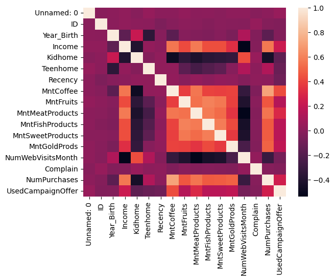

```python
ax = sns.heatmap(data.corr())
```

3- MntCoffee and Income are more dependent.

```python
for i in range (len (columns_value)):
    if (columns_value[i] == "Unnamed: 0" or columns_value[i] == "ID" or columns_value[i] == "Income"):
        continue

    print (columns_value[i])
    print (data[columns_value[i]].value_counts ())
```

```
Year_Birth
1976    89
1971    87
1975    83
1972    79
1978    77
1970    77
1973    74
1965    74
1969    71
1974    69
1956    55
1958    53
1979    53
1952    52
1977    52
1968    51
1959    51
1966    50
1954    50
1955    49
1960    49
1982    45
1963    45
1967    44
1962    44
1957    43
1951    43
1983    42
1986    42
1964    42
1980    39
1981    39
1984    38
1961    36
1953    35
1985    32
1989    30
1949    30
1950    29
```

[output cut: 205 more lines]

```
1       4
0       4
33      4
34      4
2       3
37      1
39      1
35      1
43      1
44      1
Name: NumPurchases, dtype: int64
UsedCampaignOffer
0    1631
1     609
Name: UsedCampaignOffer, dtype: int64
```

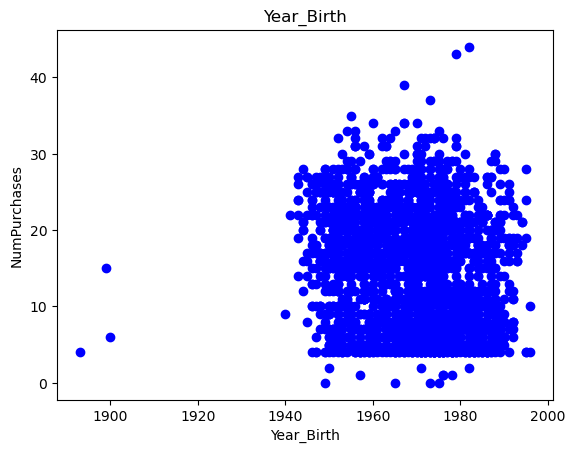

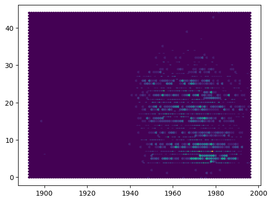

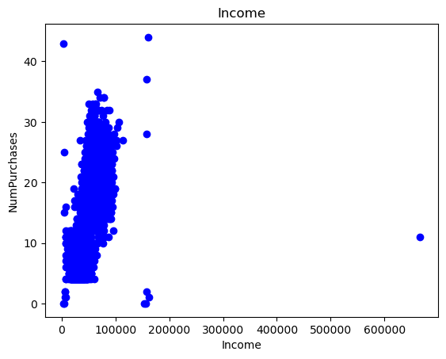

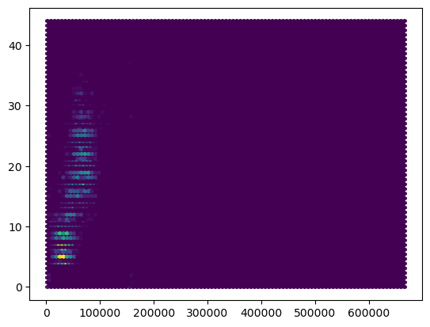

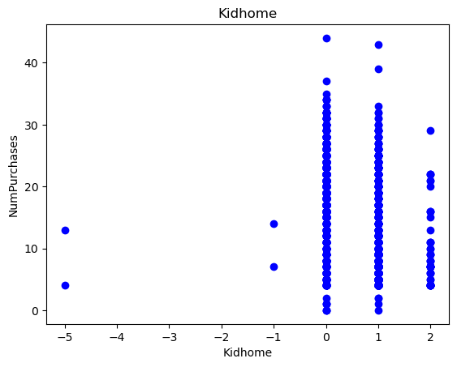

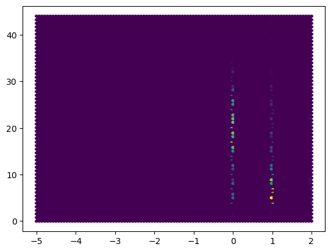

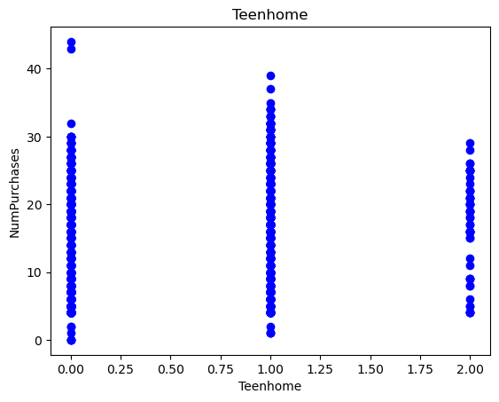

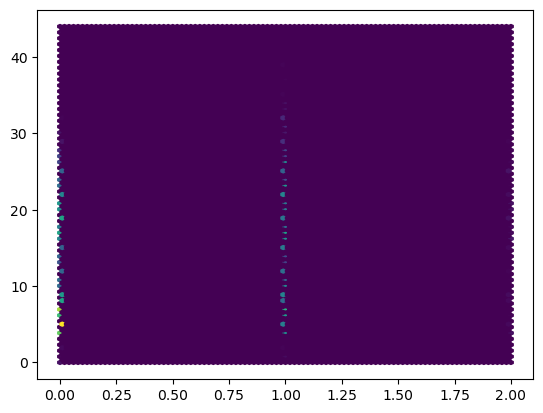

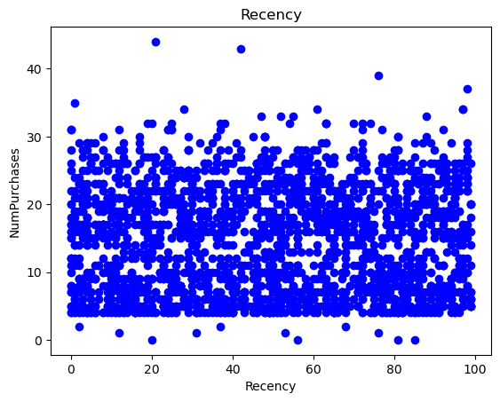

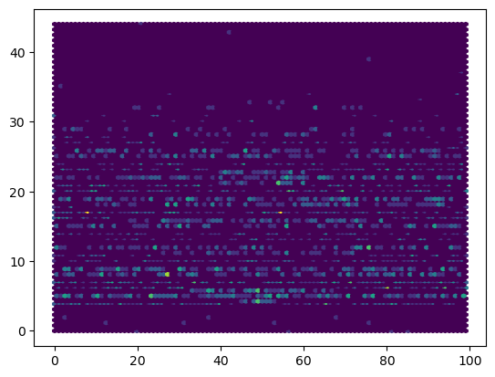

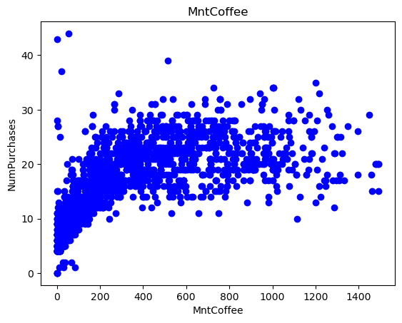

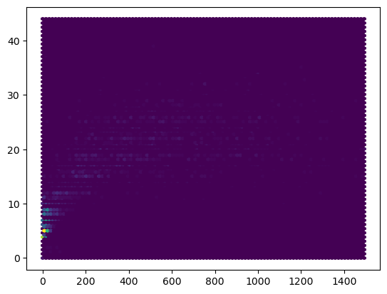

[18 more figures not shown]

```python
columns_value = list (data.columns.values)

for i in range (len (columns_value)):
    if (columns_value[i] == "Unnamed: 0" or columns_value[i] == "ID" or columns_value[i] == "Education" or columns_value[i] == "Marital_Status" or columns_value[i] == "Dt_Customer"):
        continue

    plt.scatter (data[columns_value[i]], data["NumPurchases"], color = "blue")
    plt.title (columns_value[i])
    plt.xlabel (columns_value[i])
    plt.ylabel ("NumPurchases")
    plt.show ()

    plt.hexbin (data[columns_value[i]], data["NumPurchases"])
    plt.show ()
```

## Pre Processing

7- There are some solutions for handling missing values: 1- deleting columns: this solution is used when a column has little data. Advantages: reduce dimensions and simplifies analysis. Disadvantages: lost related information. </br> 2- Filling missing values: Missing values can be filled with statistics like mean, mode. Advantages: Retain data and allows analysis without losing information. Disadvantages: changing distribution of data and errors can happen. </br> 3- Using predictive models: We can use machine learning models to predict missing values base on other features.

```python
columns_value = list (data.columns.values)

for i in range (len (columns_value)):
    print (columns_value[i], data[columns_value[i]].isnull ().any ())
```

```
Unnamed: 0 False
ID False
Year_Birth False
Education False
Marital_Status False
Income True
Kidhome False
Teenhome False
Dt_Customer False
Recency False
MntCoffee True
MntFruits False
MntMeatProducts False
MntFishProducts False
MntSweetProducts False
MntGoldProds True
NumWebVisitsMonth True
Complain False
NumPurchases False
UsedCampaignOffer False
```

```python
print (data.isnull ().sum ())
```

```
Unnamed: 0             0
ID                     0
Year_Birth             0
Education              0
Marital_Status         0
Income               223
Kidhome                0
Teenhome               0
Dt_Customer            0
Recency                0
MntCoffee            205
MntFruits              0
MntMeatProducts        0
MntFishProducts        0
MntSweetProducts       0
MntGoldProds          13
NumWebVisitsMonth    200
Complain               0
NumPurchases           0
UsedCampaignOffer      0
dtype: int64
```

8- Income and MntCoffee and NumWebVisitsMonth have more missing values

We fill missing values with column's mean becaues these columns are important and we can't delete them.

9- Normalizing is rescale values of a feature between 0 and 1 and it is used for setting values of all features between two static number and all features have same scale. If we use one feature it is not necessary to normalize but if we use more than one feature we should normalize.

10- If the values are dependent to each other and have levels we can assign a number to each value. If the values are independent from each other we can use one hot method.

11- yes, We can delete some columns. Some columns have irrelevant information and they aren't useful for us for example we can delete ID column.

12- Usually train ratio is about 80% and test ratio is about 20%. </br> Splitting methods: 1- Random splitting: split data randomly. 2- Stratified splitting: split data base on a specific feature. 3- Cross validation: use multiple rounds of splitting with different ratio.

13- A validation data set is a data-set of examples used to tune the hyperparameters of a classifier.

14- It is a technique to find performance of a model. It partitons data to k subsets with approximately same size. The model is trained and evaluated K times, using different combinations of these subsets. In each time one of the sebsets is held out as the validation set.

```python
data.drop ("Unnamed: 0", axis = 1, inplace = True)
data.drop ("ID", axis = 1, inplace = True)

data["Year_Birth"] = 2023 - data["Year_Birth"]
data.rename (columns = {"Year_Birth" : "Age"}, inplace = True)
```

```python
data["Dt_Customer"] = pd.to_datetime (data["Dt_Customer"])
data["Dt_Customer"] = 2023 - data["Dt_Customer"].dt.year
```

```
C:\Users\Mohammad Reza\AppData\Local\Temp\ipykernel_16812\534640043.py:1: UserWarning: Parsing dates in DD/MM/YYYY format when dayfirst=False (the default) was specified. This may lead to inconsistently parsed dates! Specify a format to ensure consistent parsing.
  data["Dt_Customer"] = pd.to_datetime (data["Dt_Customer"])
```

```python
columns_value = list (data.columns.values)

for i in range (len (columns_value)):
    if (data[columns_value[i]].isnull ().any ()):
        data[columns_value[i]].fillna (int (data[columns_value[i]].mean ()), inplace = True)
```

```python
data["Education"].replace ({"Basic" : 1, "2n Cycle" : 2, "Graduation" : 3, "Master" : 4, "PhD" : 5}, inplace = True)
```

```python
rows = data[data["Marital_Status"] == "YOLO"].index
data.drop (rows, inplace = True)

data = data.join (pd.get_dummies (data.Marital_Status))
data.drop ("Marital_Status", axis = 1, inplace = True)
```

```python
rows = data[data["Kidhome"] < 0].index
data.drop (rows, inplace = True)
```

```python
rows = data[data["Age"] > 100].index
data.drop (rows, inplace = True)
```

```python
rows = data[data["Income"] > 500000].index
data.drop (rows, inplace = True)
```

```python
rows = data[data["MntMeatProducts"] > 1500].index
data.drop (rows, inplace = True)
```

```python
msk = np.random.rand (len (data)) < 0.8
train = data[msk]
test = data[~msk]
```

```python
train_x = train.drop ("NumPurchases", axis = 1)
train_y = train["NumPurchases"]

test_x = test.drop ("NumPurchases", axis = 1)
test_y = test["NumPurchases"]
```

# Linear Regression

Main form of simple linear regression function: $$f(x) = \alpha x + \beta$$

- step 1: Compute RSS of the training data

$$ RSS = \Sigma (y_i - (\hat{\beta} + \hat{\alpha} * x_i) )^2 $$

- step 2: Compute the derivatives of the RSS function in terms of $\alpha$ and $\beta$, and set them equal to 0 to find the desired parameters

$$ \frac{\partial RSS}{\partial \beta} = \Sigma (-f(x_i) + \hat{\beta} + \hat{\alpha} * x_i) = 0$$$$ \to \beta = \hat{y} - \hat{\alpha} \hat{x} \to (1)$$$$ \frac{\partial RSS}{\partial \alpha} = \Sigma (-2 x_i y_i + 2 \hat{\beta} x_i + 2\hat{\alpha} x_i ^ 2) = 0 \to (2)$$$$ (1) , (2) \to \hat{\alpha} = \frac{\Sigma{(x_i - \hat{x})(y_i - \hat{y})}}{\Sigma{(x_i - \hat{x})^2}} $$$$ \hat{\beta} = y - \hat{a} x$$

Based on the above formula, implement the function below to compute the parameters of a simple linear regression

```python
def simple_linear_regression(input_feature, output):
    x = np.array (input_feature)
    y = np.array (output)

    mean1 = np.mean (x)
    mean2 = np.mean (y)

    alpha = np.sum ((x - mean1) * (y - mean2)) / np.sum ((x - mean1) ** 2)

    beta = mean2 - (alpha * mean1)

    return alpha, beta
```

Now complete this `get_regression_predictions(...)` function to predict the value of given data based on the calculated intercept and slope

```python
def get_regression_predictions(input_feature, bias, slope):
    predicted = slope * input_feature + bias
    return predicted
```

Now that we have a model and can make predictions, let's evaluate our model using Root Mean Square Error (RMSE). RMSE is the square root of the mean of the squared differences between the residuals, and the residuals is just a fancy word for the difference between the predicted output and the true output.

Complete the following function to compute the RSME of a simple linear regression model given the input_feature, output, intercept and slope:

```python
def get_root_mean_square_error(predicted_values, outputs):
    root_mean_square_error = np.sqrt (np.mean ((predicted_values - outputs) ** 2))
    return root_mean_square_error
```

The RMSE has no bound, thus it becomes challenging to determine whether a particular RMSE value is considered good or bad without any reference point. Instead, we use R2 score. The R2 score is calculated by comparing the sum of the squared differences between the actual and predicted values of the dependent variable to the total sum of squared differences between the actual and mean values of the dependent variable. The R2 score is formulated as below:

$$R^2 = 1 - \frac{SSres}{SStot} = 1 - \frac{\sum_{i=1}^{n} (y_{i,true} - y_{i,pred})^2}{\sum_{i=1}^{n} (y_{i,true} - \bar{y}_{true})^2} $$

Complete the following function to calculate the R2 score of a given input_feature, output, bias, and slope:

```python
def get_r2_score(predicted_values, outputs):
    outputs_mean = np.mean (outputs)
    r2_score = 1 - np.sum ((outputs - predicted_values) ** 2) / np.sum ((outputs - outputs_mean) ** 2)
    return r2_score
```

Now calculate the fitness of the model. Remember to provide explanation for the outputs in your code!

```
RSME: 5.661928864530368
R2 Score: 0.4486064469510984
```

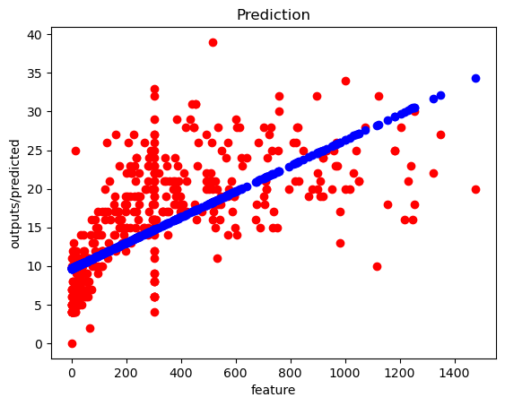

```python
designated_feature_list = []
feature = np.array (train_x["MntCoffee"])
outputs = np.array (train_y)

feature2 = np.array (test_x["MntCoffee"]);
outputs2 = np.array (test_y)

alpha, beta = simple_linear_regression (feature, outputs)
predicted = get_regression_predictions (feature2, beta, alpha)
root_meat_squre_root = get_root_mean_square_error (predicted, outputs2)
r2_score = get_r2_score (predicted, outputs2)

print ("RSME:", root_meat_squre_root)
print ("R2 Score:", r2_score)

plt.scatter (feature2, outputs2, color = "red")
plt.scatter (feature2, predicted, color = "blue")
plt.title ("Prediction")
plt.xlabel ("feature")
plt.ylabel ("outputs/predicted")

plt.show ()
```

```
RSME: 6.0278727380119115
R2 Score: 0.37502734415897254
```

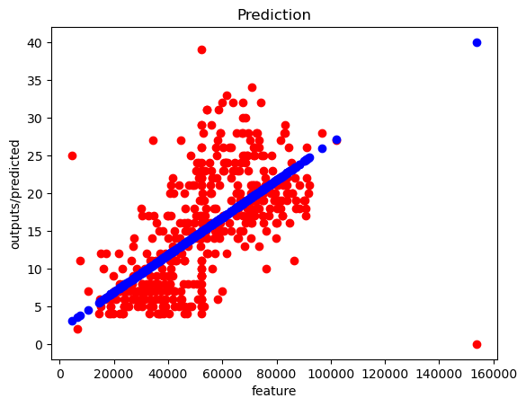

```python
designated_feature_list = []
feature = np.array (train_x["Income"])
outputs = np.array (train_y)

feature2 = np.array (test_x["Income"]);
outputs2 = np.array (test_y)

alpha, beta = simple_linear_regression (feature, outputs)
predicted = get_regression_predictions (feature2, beta, alpha)
root_meat_squre_root = get_root_mean_square_error (predicted, outputs2)
r2_score = get_r2_score (predicted, outputs2)

print ("RSME:", root_meat_squre_root)
print ("R2 Score:", r2_score)

plt.scatter (feature2, outputs2, color = "red")
plt.scatter (feature2, predicted, color = "blue")
plt.title ("Prediction")
plt.xlabel ("feature")
plt.ylabel ("outputs/predicted")

plt.show ()
```

I selected MntCoffee and Income for linear regression because these two features are more dependent to target column.

15- The calculations are base on derivatives and minimizing cost functions

16- It seems MntCoffee is more suitable because it is more dependent to the target column.

17- RSS (Residual Sum of Squares): It is the sum of the squared differences between predicted and actual values. It is useful for evaluating the overall accuracy of a model/ </br> MSE (Mean Squared Error): It is the average of the squared differences between predicted and actual values. </br> RMSE (Root Mean Squared Error): It is the square root of the average squared differences between the predicted values and the actual values. </br> R2 Score: R2 Score measures the proportion of the variance in the dependent variable that is predictable from the independent variables.

18- RMSE is between 0 and inf and lower values are better. R2 Score is between 0 and 1 and values closer to 1 are better. According to values we have a medium model.

# Multiple Regression

Multiple regression is a statistical technique that aims to model the relationship between a dependent variable and two or more independent variables.

Multiple regression with n independent variables is expressed as follows:

$$f(x) = \beta _{0} + \beta_{1} x_{1} + \beta_{2} x_{2} + \beta_{3} x_{3} + \beta_{4} x_{4} + ... + \beta_{n} x_{n} + c $$

To optimize the model for accurate predictions, multiple regression commonly employs iterative algorithms such as gradient descent.

The main goal of the optimization process is to make our predictions as close as possible to the actual values. We measure the prediction error using a cost function, usually denoted as $J(\beta)$.

$$ J(\beta)= \frac {1}{2m} Σ_{i=0}^{m-1}(y_i - (\hat \beta _{0} + \hat \beta_{1} x_{1} + \hat \beta_{2} x_{2} + \hat \beta_{3} x_{3} + \hat \beta_{4} x_{4} + ... + \hat \beta_{n} x_{n}) )^2 $$

Gradient descent iteratively adjusts the coefficients $(\beta_i)$ to minimize the cost function. The update rule for each coefficient is:

$$\beta_{i} = \beta _ {i} - \alpha \frac {∂J(\beta)}{∂\beta_{i}}$$$$ \frac {∂J(\beta)}{∂\beta_{i}} = \frac {1}{m}Σ_{j=0}^{m-1}(y_j - (\hat \beta _{0} + \hat \beta_{1} x_{j1} + \hat \beta_{2} x_{j2} + \hat \beta_{3} x_{j3} + \hat \beta_{4} x_{j4} + ... + \hat \beta_{n} x_{jn})) x_{ji} $$

## Predicting output given regression weights

Based on the formula above and [np.dot()](https://numpy.org/doc/stable/reference/generated/numpy.dot.html) method, complete this function to compute the predictions for an entire matrix of features given the matrix, bias, and the weights. Provide an explanation of np.dot method and the reasoning behind using this method in your code:

```python
def predict_output(feature_matrix, weights, bias):
    predictions = np.dot (feature_matrix, weights) + bias
    return predictions
```

## Computing the Derivative

As we saw, the cost function is the sum over the data points of the squared difference between an observed output and a predicted output.

Since the derivative of a sum is the sum of the derivatives, we can compute the derivative for a single data point and then sum over data points. We can write the squared difference between the observed output and predicted output for a single point as follows:

$$ (output - (const* w _{0} + [feature_1] * w_{1} + ...+ [feature_n] * w_{n} ))^2 $$

With n feautures and a const , So the derivative will be :

$$ 2 * (output - (const* w _{0} + [feature_1] * w_{1} + ...+ [feature_n] * w_{n} )) $$

The term inside the paranethesis is just the error (difference between prediction and output). So we can re-write this as:

$$2 * error*[feature_i] $$

That is, the derivative for the weight for feature i is the sum (over data points) of 2 times the product of the error and the feature itself. In the case of the constant then this is just twice the sum of the errors!

Recall that twice the sum of the product of two vectors is just twice the dot product of the two vectors. Therefore the derivative for the weight for feature_i is just two times the dot product between the values of feature_i and the current errors.

With this in mind, complete the following derivative function which computes the derivative of the weight given the value of the feature (over all data points) and the errors (over all data points).

```python
def feature_derivative(errors, feature):
    derivative = 2 * np.dot (errors, feature)
    return derivative
```

## Gradient Descent

Now we will write a function that performs a gradient descent. The basic premise is simple. Given a starting point we update the current weights by moving in the negative gradient direction. Recall that the gradient is the direction of increase and therefore the negative gradient is the direction of decrease and we're trying to minimize a cost function.

The amount by which we move in the negative gradient direction is called the 'step size'. We stop when we are 'sufficiently close' to the optimum. We define this by requiring that the magnitude (length) of the gradient vector to be smaller than a fixed 'tolerance'.

With this in mind, complete the following gradient descent function below using your derivative function above. For each step in the gradient descent we update the weight for each feature befofe computing our stopping criteria.

```python
def regression_gradient_descent(feature_matrix, outputs, initial_weights, bias, step_size, tolerance):
    weights = initial_weights

    while True:
        predictions = predict_output (feature_matrix, weights, bias)
        err = outputs - predictions
        g_weights = []

        for i in range (len (weights)):
            d = feature_derivative (err, feature_matrix[:,i])
            g_weights.append (d)

        g_weights = np.array (g_weights)

        weights = weights + step_size * g_weights
        bias = bias + step_size * (2 * np.sum (err))

        gradiant_length = np.sqrt (np.sum (g_weights ** 2))

        if (gradiant_length < tolerance):
            break

    return weights, bias
```

```python
# Utility functions for multiple regression

def normalize_features(chosen_features, data_frame):
    for feature in chosen_features:
        data_frame[feature] = (data_frame[feature] - data_frame[feature].mean()) / data_frame[feature].std()
    return data_frame


def n_feature_regression(chosen_feature_matrix, target_matrix, keywords):
    initial_weights = keywords['initial_weights']
    step_size = keywords['step_size']
    tolerance = keywords['tolerance']
    bias = keywords['bias']

    weights, bias = regression_gradient_descent(chosen_feature_matrix, target_matrix, initial_weights, bias, step_size,
                                                tolerance)

    return weights, bias

def get_weights_and_bias(chosen_features):
    """
    Computes the weights and bias for a general n feature model.
    :param chosen_features:  list of features to perform multiple regression on
    :return: chosen_feature_matrix, computed weights and bias via regression
    """

    # ToDo
    #  Would selecting different initial weights make any difference?
    #  Explain your answer.
    keywords = {
        'initial_weights': np.array([.5]*len(chosen_features)),
        'step_size': 1.e-8,
        'tolerance': 1.e-5,
        'bias': 0
    }

    chosen_feature_dataframe = train_x[chosen_features]
    # ToDo
    #  Why are the features normalized?

    chosen_feature_dataframe = normalize_features(chosen_features, chosen_feature_dataframe)
    chosen_feature_matrix = chosen_feature_dataframe.to_numpy()

    target_column = train_y
    target_matrix = target_column.to_numpy()

    train_weights, bias = n_feature_regression(chosen_feature_matrix, target_matrix, keywords)

    return chosen_feature_matrix, train_weights, bias
```

## Two Feature Regression

In this part, you should choose 2 features and implement multiple regression on them :

```python
chosen_features = []
chosen_features.append ("Income")
chosen_features.append ("MntCoffee")

chosen_feature_matrix, train_weights, bias = get_weights_and_bias (chosen_features)
```

```
C:\Users\Mohammad Reza\AppData\Local\Temp\ipykernel_16812\2265730981.py:5: SettingWithCopyWarning:
A value is trying to be set on a copy of a slice from a DataFrame.
Try using .loc[row_indexer,col_indexer] = value instead

See the caveats in the documentation: https://pandas.pydata.org/pandas-docs/stable/user_guide/indexing.html#returning-a-view-versus-a-copy
  data_frame[feature] = (data_frame[feature] - data_frame[feature].mean()) / data_frame[feature].std()
```

```
RMSE: 5.020016988110672
R2 Score: 0.5645777010112474
```

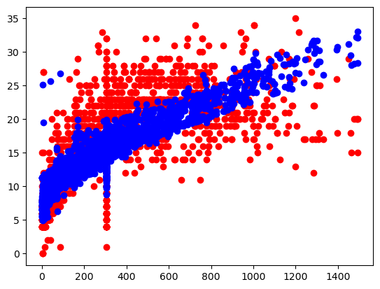

```python
predictions = predict_output (chosen_feature_matrix, train_weights, bias)

feature = np.array (train_x["MntCoffee"])
outputs = np.array (data["NumPurchases"])
root_meat_squre_root = get_root_mean_square_error (predictions, train_y)
r2_score = get_r2_score (predictions, train_y)

print ("RMSE:", root_meat_squre_root)
print ("R2 Score:", r2_score)

plt.scatter (feature, train_y, color = "red")
plt.scatter (feature, predictions, color = "blue")

plt.show ()
```

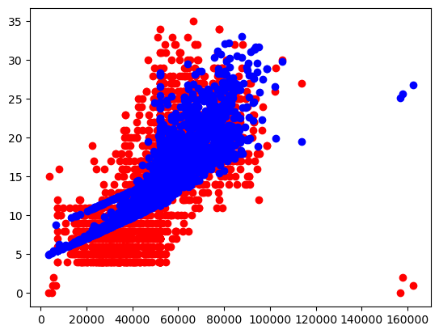

```python
feature = np.array (train_x["Income"])

plt.scatter (feature, train_y, color = "red")
plt.scatter (feature, predictions, color = "blue")

plt.show ()
```

I selected MntCoffee and Income for two feature regression because these two features are more dependent to target column.

## Three Feature Regression

Now repeat the steps for 3 features

```python
chosen_features = []
chosen_features.append ("Income")
chosen_features.append ("MntCoffee")
chosen_features.append ("MntMeatProducts")

chosen_feature_matrix, train_weights, bias = get_weights_and_bias (chosen_features)
```

```
C:\Users\Mohammad Reza\AppData\Local\Temp\ipykernel_16812\2265730981.py:5: SettingWithCopyWarning:
A value is trying to be set on a copy of a slice from a DataFrame.
Try using .loc[row_indexer,col_indexer] = value instead

See the caveats in the documentation: https://pandas.pydata.org/pandas-docs/stable/user_guide/indexing.html#returning-a-view-versus-a-copy
  data_frame[feature] = (data_frame[feature] - data_frame[feature].mean()) / data_frame[feature].std()
```

```
RMSE: 4.990554931326491
R2 Score: 0.5696736168305253
```

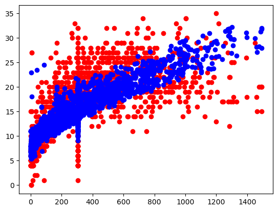

```python
predictions = predict_output (chosen_feature_matrix, train_weights, bias)

feature = np.array (train_x["MntCoffee"])
outputs = np.array (data["NumPurchases"])
root_meat_squre_root = get_root_mean_square_error (predictions, train_y)
r2_score = get_r2_score (predictions, train_y)

print ("RMSE:", root_meat_squre_root)
print ("R2 Score:", r2_score)

plt.scatter (feature, train_y, color = "red")
plt.scatter (feature, predictions, color = "blue")

plt.show ()
```

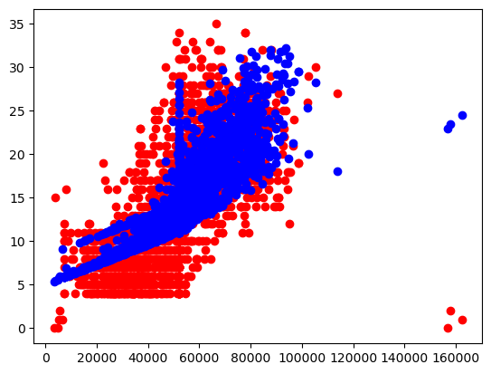

```python
feature = np.array (train_x["Income"])

plt.scatter (feature, train_y, color = "red")
plt.scatter (feature, predictions, color = "blue")

plt.show ()
```

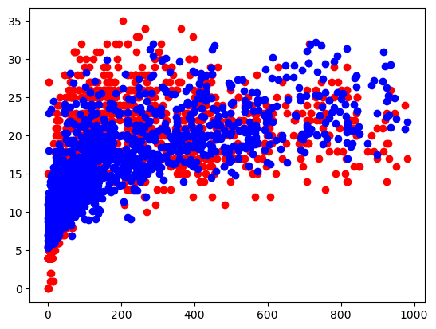

```python
feature = np.array (train_x["MntMeatProducts"])

plt.scatter (feature, train_y, color = "red")
plt.scatter (feature, predictions, color = "blue")

plt.show ()
```

I selected MntCoffee and Income and MntMeatProducts for three feature regression because these three features are more dependent to target column.

## Five Feature Regression

Finally, repeat the steps for 5 features

Explain the differences in the results and the reasoning behind these variations.

```python
chosen_features = []
chosen_features.append ("Income")
chosen_features.append ("MntCoffee")
chosen_features.append ("MntMeatProducts")
chosen_features.append ("MntFruits")
chosen_features.append ("MntFishProducts")

chosen_feature_matrix, train_weights, bias = get_weights_and_bias (chosen_features)
```

```
C:\Users\Mohammad Reza\AppData\Local\Temp\ipykernel_16812\2265730981.py:5: SettingWithCopyWarning:
A value is trying to be set on a copy of a slice from a DataFrame.
Try using .loc[row_indexer,col_indexer] = value instead

See the caveats in the documentation: https://pandas.pydata.org/pandas-docs/stable/user_guide/indexing.html#returning-a-view-versus-a-copy
  data_frame[feature] = (data_frame[feature] - data_frame[feature].mean()) / data_frame[feature].std()
```

```
RMSE: 4.876318965175073
R2 Score: 0.589148852854648
```

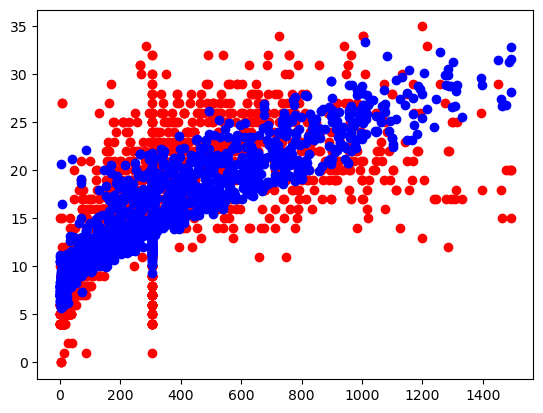

```python
predictions = predict_output (chosen_feature_matrix, train_weights, bias)

feature = np.array (train_x["MntCoffee"])
outputs = np.array (data["NumPurchases"])
root_meat_squre_root = get_root_mean_square_error (predictions, train_y)
r2_score = get_r2_score (predictions, train_y)

print ("RMSE:", root_meat_squre_root)
print ("R2 Score:", r2_score)

plt.scatter (feature, train_y, color = "red")
plt.scatter (feature, predictions, color = "blue")

plt.show ()
```

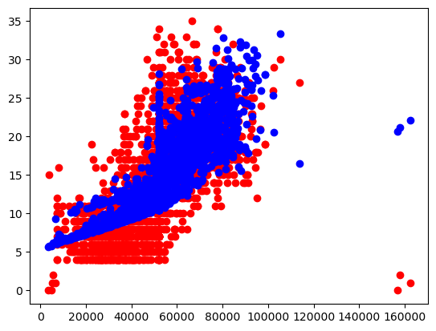

```python
feature = np.array (train_x["Income"])

plt.scatter (feature, train_y, color = "red")
plt.scatter (feature, predictions, color = "blue")

plt.show ()
```

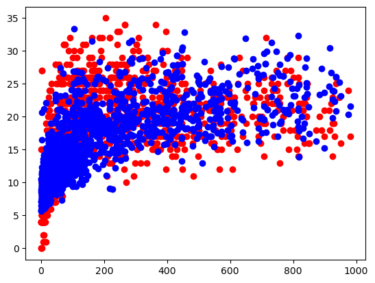

```python
feature = np.array (train_x["MntMeatProducts"])

plt.scatter (feature, train_y, color = "red")
plt.scatter (feature, predictions, color = "blue")

plt.show ()
```

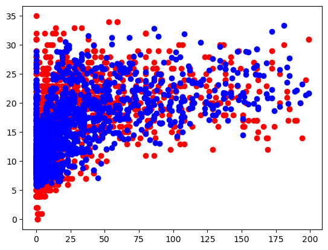

```python
feature = np.array (train_x["MntFruits"])

plt.scatter (feature, train_y, color = "red")
plt.scatter (feature, predictions, color = "blue")

plt.show ()
```

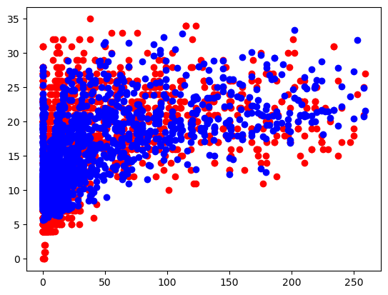

```python
feature = np.array (train_x["MntFishProducts"])

plt.scatter (feature, train_y, color = "red")
plt.scatter (feature, predictions, color = "blue")

plt.show ()
```

I selected MntCoffee and Income and MntMeatProducts and MntFruits and MntFishProducts for linear regression because these five features are more dependent to target column.

Acording to values we have better models than linear regression. It seems models with more feature is better.

## Classification

```python
rate = []
median = data["NumPurchases"].median ()

for i in data.index:
    if (data["NumPurchases"][i] >= median):
        rate.append ("HIGH")
    else:
        rate.append ("LOW")

data["PurchaseRate"] = rate
```

```python
data2 = data.copy ()
```

```python
data2.drop ("NumPurchases", axis = 1, inplace = True)
feature_names = data2.columns[:-1]
```

```python
x_train, x_test, y_train, y_test = train_test_split (data2[feature_names], data2["PurchaseRate"], random_state = 0)
```

### Decision Tree

```python
clf = tree.DecisionTreeClassifier (max_depth = 8)
clf.fit (x_train, y_train)
```

```
DecisionTreeClassifier(max_depth=8)
```

```python
y_pred1 = clf.predict(x_test)
print("Accuracy:", accuracy_score(y_test, y_pred1))
```

```
Accuracy: 0.926391382405745
```

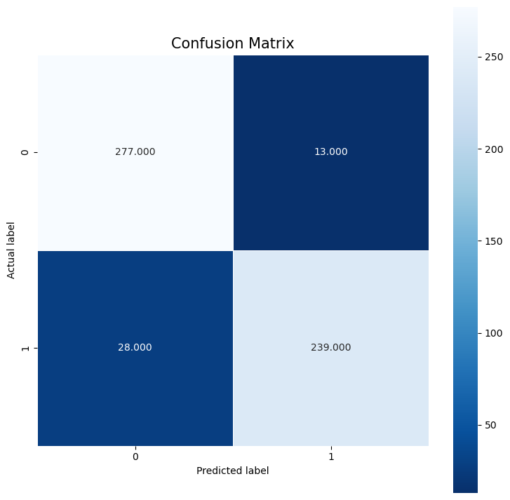

```python
cm = confusion_matrix(y_test, y_pred1)
plt.figure(figsize=(9,9))
sns.heatmap(cm, annot=True, fmt=".3f", linewidths=.5, square = True, cmap = 'Blues_r');
plt.ylabel("Actual label");
plt.xlabel("Predicted label");
all_sample_title = "Confusion Matrix"
plt.title(all_sample_title, size = 15);
```

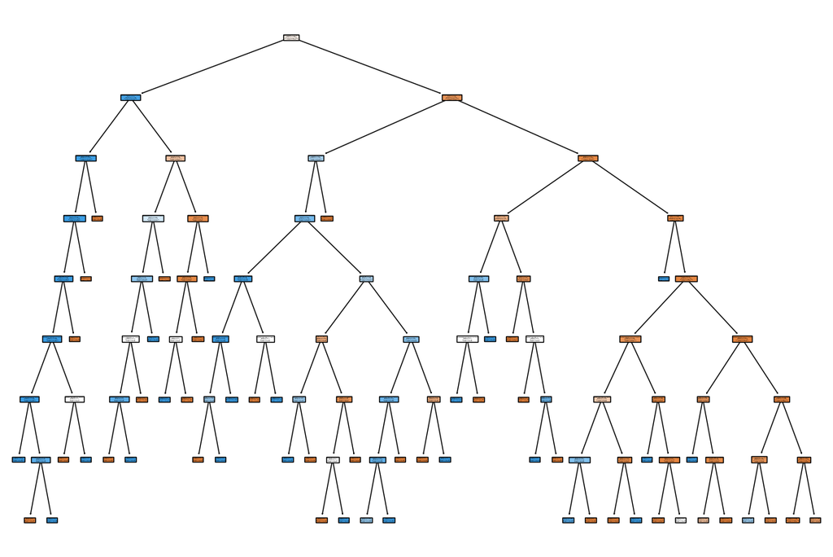

```python
fig = plt.figure(figsize=(15,10))
_ = tree.plot_tree(clf, feature_names=list(feature_names), class_names=["LOW", "HIGH"], filled=True)
```

```
Accuracy: 0.9228007181328546
```

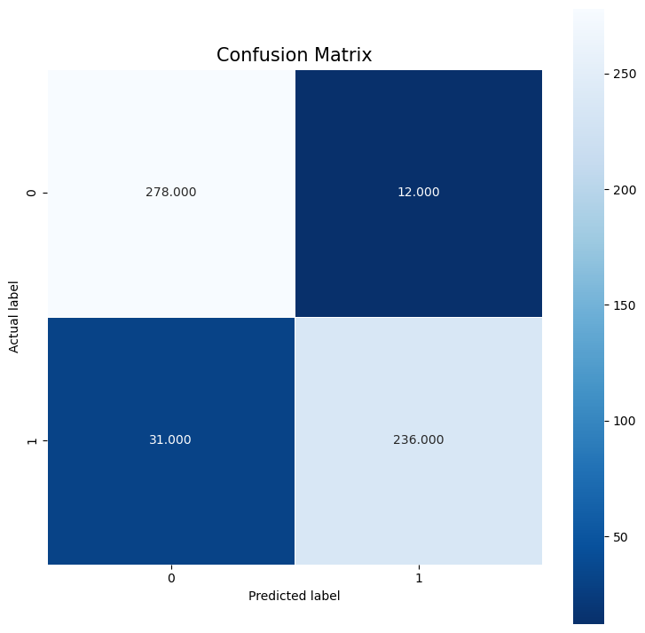

```python
clf = tree.DecisionTreeClassifier (max_depth = 5)
clf.fit (x_train, y_train)

y_pred1 = clf.predict(x_test)
print("Accuracy:", accuracy_score(y_test, y_pred1))

cm = confusion_matrix(y_test, y_pred1)
plt.figure(figsize=(9,9))
sns.heatmap(cm, annot=True, fmt=".3f", linewidths=.5, square = True, cmap = 'Blues_r');
plt.ylabel("Actual label");
plt.xlabel("Predicted label");
all_sample_title = "Confusion Matrix"
plt.title(all_sample_title, size = 15);
```

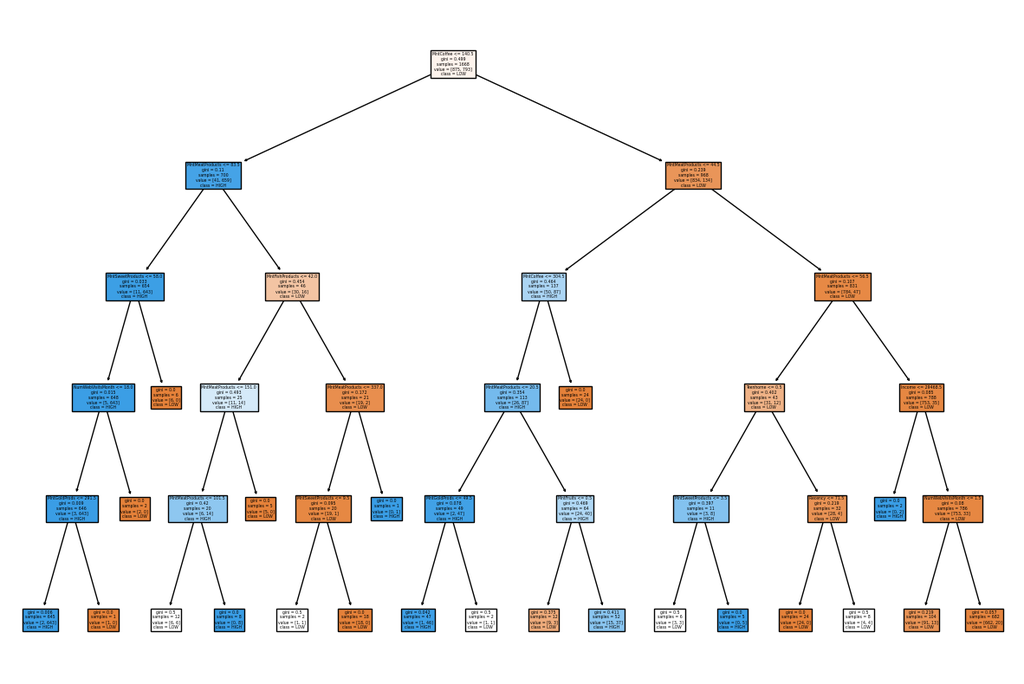

```python
fig = plt.figure(figsize=(15,10))
_ = tree.plot_tree(clf, feature_names=list(feature_names), class_names=["LOW", "HIGH"], filled=True)
```

```python
acc = []
depths = list (range (1, 21))

for i in range (20):
    clf = tree.DecisionTreeClassifier (max_depth = depths[i])
    clf.fit (x_train, y_train)
    y_pred1 = clf.predict(x_test)
    acc.append (accuracy_score(y_test, y_pred1))
```

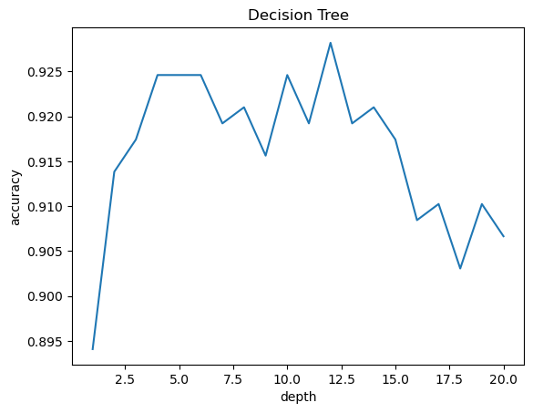

```python
plt.plot (depths, acc)
plt.title ("Decision Tree")
plt.xlabel ("depth")
plt.ylabel ("accuracy")
plt.show ()
```